# Simulate from the BCGP Model

Casey Davis

2019-06-29

## Simulating from (and Plotting) a BCGP model

Simulating from the Bayesian Composite Gaussian Process model is straightforward. The function simulate_from_model has options that allow the user to simulate from a stationary or non-stationary model, a composite or non-composite model, deterministic or noisy data, and any combination of these. NOTE: the function bcgpsims can be substituted for `simulate_from_model()`. These two functions create identical S4 objects of class `bcgpsims`. It is the user’s preference.

The arguments `composite`, `stationary`, and `noise` determine the type of model the process will be generated from and are straightforward.

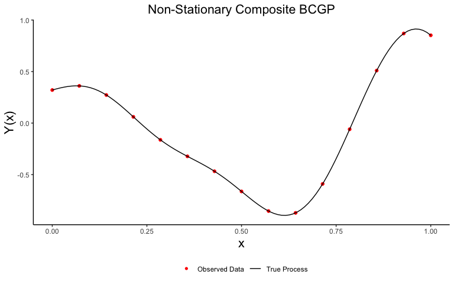

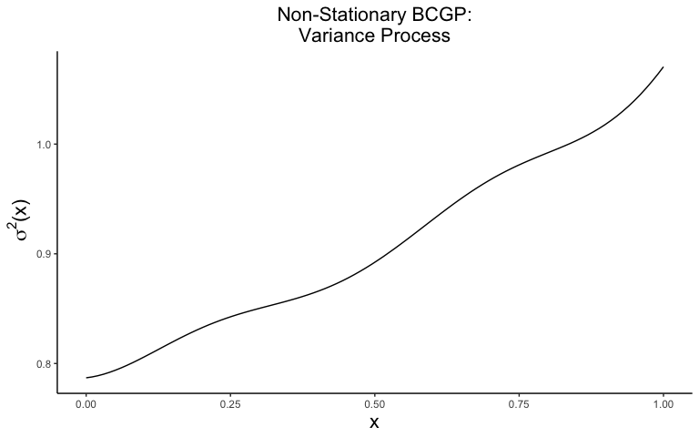

```r
nsComp1 <- simulate_from_model(composite = TRUE, stationary = FALSE,
                               noise = FALSE)
z <- plot(nsComp1)
```

Other parameters can control the dimension of the data (`d`), the number of training data locations (`n`), and the number of test data locations (`nTest`):

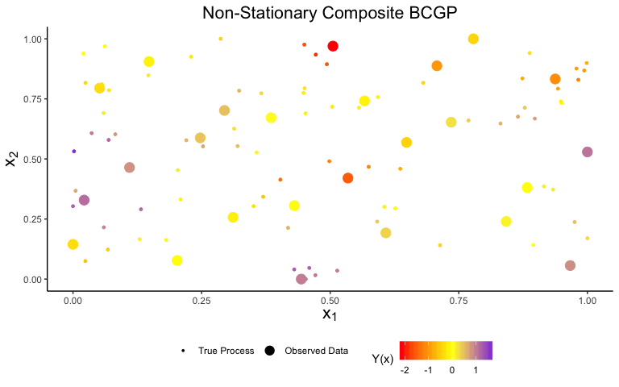

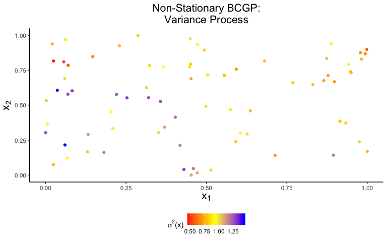

```r
nsComp2 <- simulate_from_model(composite = TRUE, stationary = FALSE,
                               noise = FALSE, d = 2, n = 25, nTest = 75)
z <- plot(nsComp2)
```

The two simulations above were simulated with randomly generated parameters. The user can choose the parameters for the model if they wish. It is best to first use the helper function `create_parameter_list()`, which creates a list of parameters, modify that list, and then use that list as the `parameters` argument in the `simulate_from_model()` function.

```r
params <- create_parameter_list(composite = FALSE, stationary = TRUE,
                              noise = FALSE, d = 1)
params
```

```
$beta0
[1] 0

$rho
[1] 0.6143854

$sigma2
[1] 1

$sig2eps
[1] 0
```

```r
params$rho <- 0.9
params
```

```
$beta0
[1] 0

$rho
[1] 0.9

$sigma2
[1] 1

$sig2eps
[1] 0
```

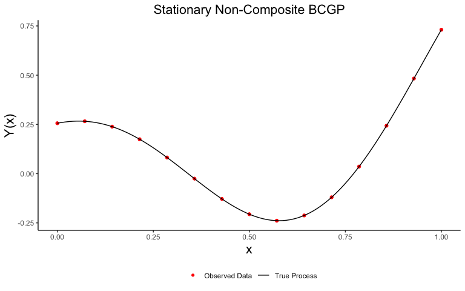

```r
changeParams <- simulate_from_model(composite = FALSE, stationary = TRUE,
                               parameters = params)
z <- plot(changeParams, process = "y")
```

The `seed` argument can be set for reproducibility and is straightforward.

If the `decompositon` argument is `TRUE`, then the simulation will return the global, local, and error processes along with the overall process. It is ignored if `composite` is `FALSE`.

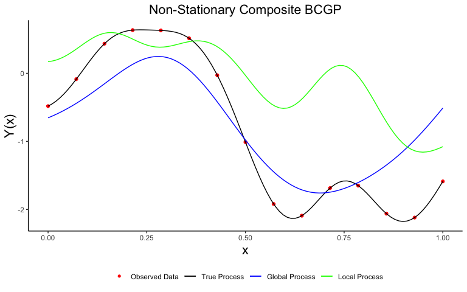

```r
decomp <- simulate_from_model(composite = TRUE, stationary = FALSE,
                              noise = FALSE, d = 1, decomposition = TRUE,
                              seed = 701691)
z <- plot(decomp, process = "y", decomposition = TRUE)
```

The optional argument `randomX1D` is relevant only with one-dimensional training data and determines whether the training data locations should be equally spaced or if they should be randomly sampled on $[0, 1]$.

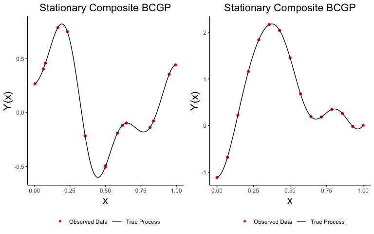

```r
params <- create_parameter_list(composite = TRUE, stationary = TRUE,
                              noise = FALSE, d = 1)

randomX <- simulate_from_model(composite = TRUE, stationary = TRUE,
                               randomX1D = TRUE, parameters = params)

seqX <- simulate_from_model(composite = TRUE, stationary = TRUE,
                            randomX1D = FALSE, parameters = params)

p1 <- plot(randomX, process = "y", print = FALSE)
p2 <- plot(seqX, process = "y", print = FALSE)

gridExtra::grid.arrange(p1, p2, ncol = 2)
```

The optional parameter `gridTest` indicates wheter the test data should be generated on a grid. For example, if `gridTest = FALSE`, then `nTest` test data locations are randomly selected on $[0, 1]^d$. However, if `gridTest = TRUE` and `gridTestSize`, the number of points per dimension, is specified, then the $gridTestSize^d$ test data locations are generated on a grid on $[0, 1]^d$ with `gridTestSize` points for each dimension.

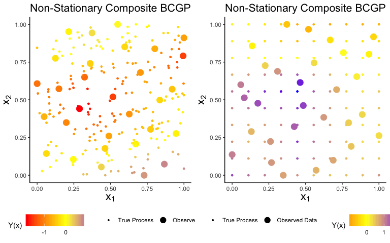

```r
params <- create_parameter_list(composite = TRUE, stationary = FALSE,
                              noise = FALSE, d = 2)

randomXTest <- simulate_from_model(composite = TRUE, stationary = FALSE, d = 2,
                                  parameters = params, gridTest = FALSE)

gridXTest <- simulate_from_model(composite = TRUE, stationary = FALSE, d = 2,
                                 parameters = params,
                                 gridTest = TRUE, gridTestSize = 10)

p3 <- plot(randomXTest, process = "y", print = FALSE)
p4 <- plot(gridXTest, process = "y", print = FALSE)

gridExtra::grid.arrange(p3, p4, ncol = 2)
```

One reason for the option for the grid is plotting. If `gridTest = TRUE`, then the plot (in 2-D) can be made with the `geom_raster` function in the `ggplot2` package.

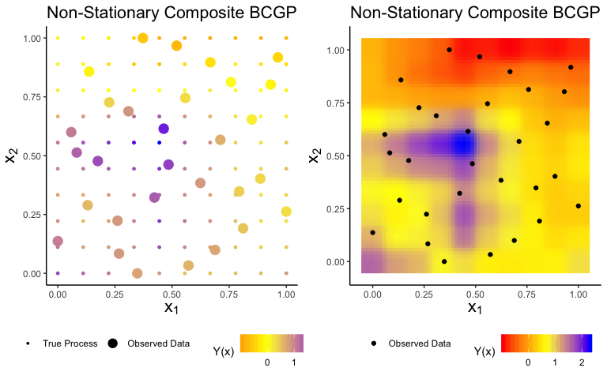

```r
p5 <- plot(gridXTest, process = "y", print = FALSE, raster = FALSE)
p6 <- plot(gridXTest, process = "y", print = FALSE, raster = TRUE)

gridExtra::grid.arrange(p5, p6, ncol = 2)
```